# HW4

Author

Shuchen Wu

## Question 1

```r
# running cumulative sum by row
fun2 <- function(mat) {
  n <- nrow(mat)
  k <- ncol(mat)
  ans <- mat
  for (i in 1:n) {
    for (j in 2:k) {
      ans[i, j] <- mat[i, j] + ans[i, j - 1]
    }
  }
  ans
}

fun2alt <- function(mat) {
  t(apply(mat, 1, cumsum))
}

# test
set.seed(2315)
dat <- matrix(rnorm(200 * 100), nrow = 200)

all.equal(fun2(dat), fun2alt(dat))
```

```
[1] TRUE
```

```r
library(microbenchmark)

bm <- microbenchmark(
  original = fun2(dat),
  faster   = fun2alt(dat),
  times = 100
)

bm
```

```
Unit: microseconds
     expr      min        lq      mean  median       uq      max neval
 original 1158.619 1170.6115 1184.9627 1176.70 1189.307 1278.954   100
   faster  279.661  311.4155  443.6647  316.93  328.574 6724.697   100
```

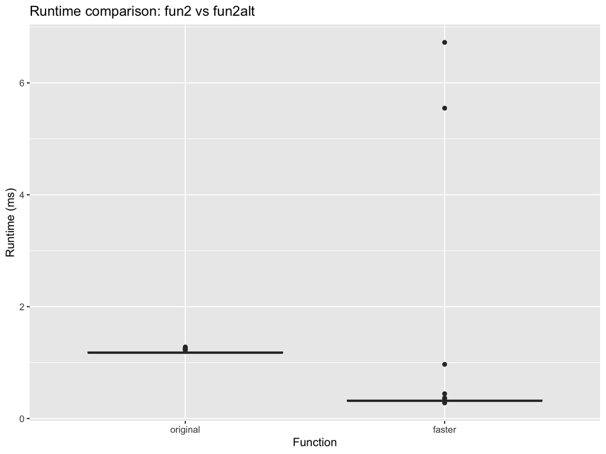

```r
library(ggplot2)

bm_df <- as.data.frame(bm)

ggplot(bm_df, aes(x = expr, y = time / 1e6)) +
  geom_boxplot() +
  labs(
    title = "Runtime comparison: fun2 vs fun2alt",
    x = "Function",
    y = "Runtime (ms)"
  )
```

The two functions give same results, and the microbenchmark and the graph shows that fun2alt is much faster than the original version.

## Question 2

```r
fun3 <- function(x) {
  out <- numeric(length(x))
  cumsum_x <- 0
  for (i in seq_along(x)) {
    if (x[i] == 0) {
      cumsum_x <- 0
    } else {
      cumsum_x <- cumsum_x + x[i]
    }
    out[i] <- cumsum_x
  }
  out
}

fun3alt = function(x) {
  cs = cumsum(x)
  z = which(x == 0)

  if (length(z) == 0) {
    return(cs)
  }

  last_zero_group = findInterval(seq_along(x), z)
  offset = c(0, cs[z])[last_zero_group + 1]

  out = cs - offset
  out[x == 0] = 0
  out
}

# test
set.seed(2315)
dat2 = sample(
  c(0, -5:5),
  size = 10000,
  replace = TRUE,
  prob = c(0.2, rep(0.8 / 11, 11))
)

all.equal(fun3(dat2), fun3alt(dat2))
```

```
[1] TRUE
```

```r
bm2 = microbenchmark(
  original = fun3(dat2),
  faster   = fun3alt(dat2),
  times = 100
)

bm2
```

```
Unit: microseconds
     expr     min       lq     mean  median      uq      max neval
 original 449.360 455.5920 469.6644 459.733 471.746  715.122   100
   faster 210.207 225.9715 292.1123 232.470 244.237 3232.563   100
```

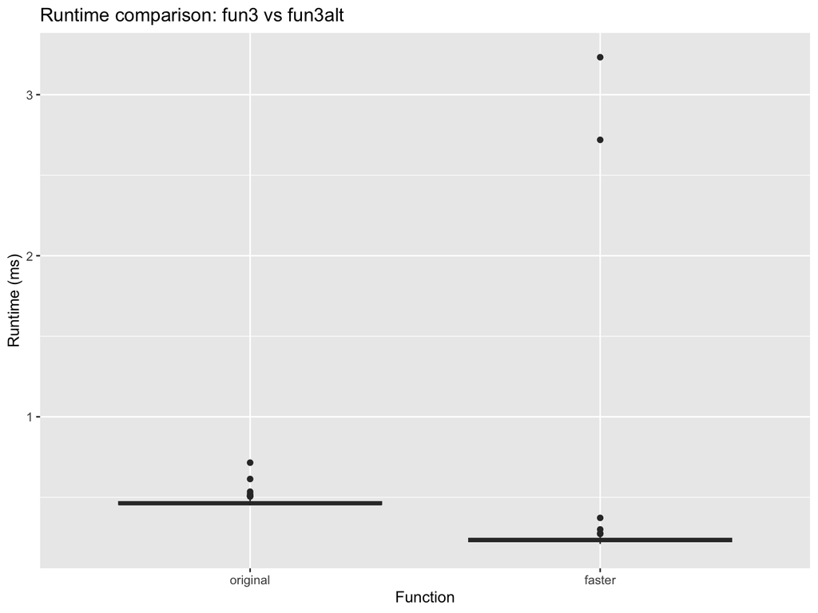

```r
library(ggplot2)

bm2_df = as.data.frame(bm2)

ggplot(bm2_df, aes(x = expr, y = time / 1e6)) +
  geom_boxplot() +
  labs(
    title = "Runtime comparison: fun3 vs fun3alt",
    x = "Function",
    y = "Runtime (ms)"
  )
```

The two functions produce identical results. Although the maximum runtime of fun3alt is larger, its min, lq, mean, median, uq runtime is smaller than that of the original function, indicating that fun3alt is generally faster overall. The graph is also indicating that.

## Question 3

```r
library(parallel)
library(ggplot2)

sim_pi = function(n = 1000, i = NULL) {
  p = matrix(runif(n * 2), ncol = 2)
  mean(rowSums(p^2) < 1) * 4
}

# serial version
set.seed(1231)
time_serial = system.time({
  ans_serial = unlist(lapply(1:4000, sim_pi, n = 10000))
  print(mean(ans_serial))
})
```

```
[1] 3.14124
```

```r
# parallel version
cl = makeCluster(4)

clusterExport(cl, "sim_pi")
clusterSetRNGStream(cl, 1231)

time_parallel = system.time({
  ans_parallel = unlist(parLapply(cl, 1:4000, sim_pi, n = 10000))
  print(mean(ans_parallel))
})
```

```
[1] 3.141578
```

```r
stopCluster(cl)

time_serial
```

```
   user  system elapsed
  0.712   0.151   0.866
```

```r
time_parallel
```

```
   user  system elapsed
  0.002   0.001   0.405
```

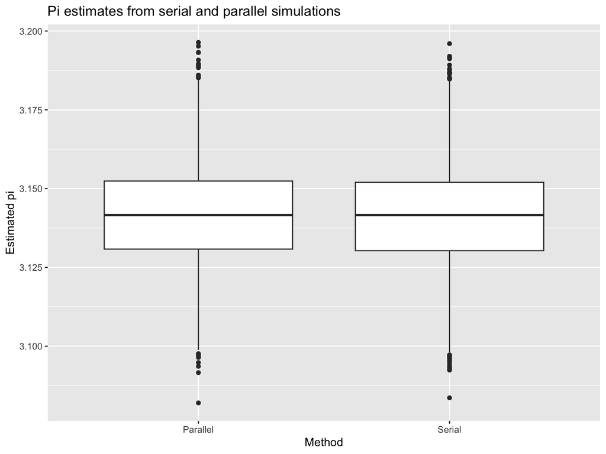

```r
pi_df = data.frame(
  estimate = c(ans_serial, ans_parallel),
  method = rep(c("Serial", "Parallel"), each = length(ans_serial))
)

ggplot(pi_df, aes(x = method, y = estimate)) +
  geom_boxplot() +
  labs(
    title = "Pi estimates from serial and parallel simulations",
    x = "Method",
    y = "Estimated pi"
  )
```

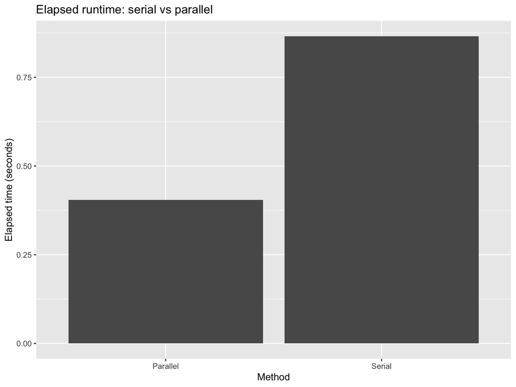

```r
time_df = data.frame(
  method = c("Serial", "Parallel"),
  elapsed = c(time_serial["elapsed"], time_parallel["elapsed"])
)

ggplot(time_df, aes(x = method, y = elapsed)) +
  geom_col() +
  labs(
    title = "Elapsed runtime: serial vs parallel",
    x = "Method",
    y = "Elapsed time (seconds)"
  )
```

Both the serial and parallel versions produced very similar estimates of pi, with sample means 3.14124 and 3.141578, and their boxplots show nearly identical distributions and ranges.

## Setup

```r
library(RSQLite)
library(DBI)

# Initialize a temporary in-memory database
con = dbConnect(RSQLite::SQLite(), ":memory:")

# Read in tables
surveys = read.csv("surveys.csv")
species = read.csv("species.csv")
plots = read.csv("plots.csv")

# Copy data.frames to database
dbWriteTable(con, "surveys", surveys, overwrite = TRUE)
dbWriteTable(con, "species", species, overwrite = TRUE)
dbWriteTable(con, "plots", plots, overwrite = TRUE)
```

## Question 4

```sql
PRAGMA table_info(surveys);
```

9 records

| cid | name | type | notnull | dflt_value | pk |
| --- | --- | --- | --- | --- | --- |
| 0 | record_id | INTEGER | 0 | NA | 0 |
| 1 | month | INTEGER | 0 | NA | 0 |
| 2 | day | INTEGER | 0 | NA | 0 |
| 3 | year | INTEGER | 0 | NA | 0 |
| 4 | plot_id | INTEGER | 0 | NA | 0 |
| 5 | species_id | TEXT | 0 | NA | 0 |
| 6 | sex | TEXT | 0 | NA | 0 |
| 7 | hindfoot_length | INTEGER | 0 | NA | 0 |
| 8 | weight | INTEGER | 0 | NA | 0 |

```sql
SELECT
  year,
  month,
  day,
  species_id,
  ROUND(weight / 1000.0, 2) AS weight_kg
FROM surveys
WHERE year = 1999
ORDER BY species_id;
```

Displaying records 1 - 10

| year | month | day | species_id | weight_kg |
| --- | --- | --- | --- | --- |
| 1999 | 1 | 17 |  | NA |
| 1999 | 2 | 21 |  | NA |
| 1999 | 2 | 21 |  | NA |
| 1999 | 2 | 21 |  | NA |
| 1999 | 3 | 15 |  | NA |
| 1999 | 3 | 15 |  | NA |
| 1999 | 3 | 15 |  | NA |
| 1999 | 4 | 17 |  | NA |
| 1999 | 4 | 18 |  | NA |
| 1999 | 4 | 18 |  | NA |

The first query uses PRAGMA table_info() to inspect the structure of the surveys table. The second query selects the three date fields, species_id, and weight converted to kilograms and rounded to two decimal places for observations from 1999, ordered alphabetically by species_id. The weight column is recorded in grams in the Portal Teaching Database, so I converted it to kilograms by dividing by 1000 and then rounded to two decimal places.

## Question 5

```sql
SELECT
  SUM(weight) AS total_weight,
  AVG(weight) AS average_weight,
  MIN(weight) AS min_weight,
  MAX(weight) AS max_weight
FROM surveys;
```

1 records

| total_weight | average_weight | min_weight | max_weight |
| --- | --- | --- | --- |
| 1377594 | 42.67243 | 4 | 280 |

```sql
SELECT
  SUM(weight) AS total_weight,
  AVG(weight) AS average_weight,
  MIN(weight) AS min_weight,
  MAX(weight) AS max_weight
FROM surveys
WHERE weight BETWEEN 5 AND 10;
```

1 records

| total_weight | average_weight | min_weight | max_weight |
| --- | --- | --- | --- |
| 24874 | 8.392038 | 5 | 10 |

Across all animals, the total weight was 1,377,594, with an average of 42.67, a minimum of 4, and a maximum of 280.

Yes, for animals weighing between 5 and 10 inclusive, the total weight was 24,874 and the average weight was 8.39, with weights ranging from 5 to 10.

## Question 6

```r
q6_result = DBI::dbGetQuery(con, "
  SELECT
    year,
    species_id,
    COUNT(*) AS count_each_year_species,
    COUNT(weight) AS nonmissing_weight_count,
    AVG(weight) AS average_weight
  FROM surveys
  GROUP BY year, species_id
  ORDER BY year, species_id;
")

q6_result
```

```
    year species_id count_each_year_species nonmissing_weight_count
1   1977                                 16                       0
2   1977         DM                     264                     184
3   1977         DO                      12                      12
4   1977         DS                      98                      32
5   1977         NL                      31                       0
6   1977         OL                      10                       3
7   1977         OT                      17                       2
8   1977         OX                       7                       3
9   1977         PE                       6                       2
10  1977         PF                      31                      23
11  1977         PP                       7                       3
12  1977         RM                       2                       2
13  1977         SH                       1                       0
14  1977         SS                       1                       0
```

[output cut: 1057 more lines]

I used a query that grouped the data by year and species_id, while keeping groups even when all weight values were missing. To make this explicit, I included both COUNT(*) and COUNT(weight). Here, COUNT(*) gives the total number of records in each year-species group, while COUNT(weight) gives the number of non-missing weight values in that group. The average weight is computed by AVG(weight), which uses only the non-missing weight observations, so it is effectively based on the nonmissing_weight_count rather than the total group count. As a result, groups with no recorded weights are still retained in the output, but their average_weight is shown as NA.

Also, I kept all observations in the query, including records with missing species_id, so that unknown species were also retained as part of the dataset summary. This query includes all observations, so rows with missing species_id appear as a separate group representing unidentified species.

## Question 7

```sql
SELECT
  taxa,
  COUNT(*) AS num_species
FROM species
GROUP BY taxa
HAVING COUNT(*) > 10;
```

2 records

| taxa | num_species |
| --- | --- |
| Bird | 13 |
| Rodent | 31 |

Only two taxa had more than 10 species: Rodent (31 species) and Bird (13 species).

## Question 8

```r
q8_result = DBI::dbGetQuery(con, "
  SELECT
    s.plot_id,
    sp.genus,
    COUNT(*) AS num_animals
  FROM surveys AS s
  INNER JOIN species AS sp
    ON s.species_id = sp.species_id
  GROUP BY s.plot_id, sp.genus
  ORDER BY s.plot_id ASC, num_animals DESC;
")

q8_result
```

```
    plot_id            genus num_animals
1         1        Dipodomys        1330
2         1      Chaetodipus         332
3         1        Onychomys         153
4         1          Neotoma          54
5         1      Perognathus          34
6         1       Peromyscus          28
7         1  Reithrodontomys          24
8         1     Spermophilus          12
9         1       Amphispiza           7
10        1 Ammospermophilus           7
11        1           Pipilo           4
12        1       Sylvilagus           2
13        1           Rodent           1
14        1          Baiomys           1
```

[output cut: 360 more lines]

## Question 9

```sql
SELECT
  p.plot_type,
  sp.species_id,
  sp.genus,
  sp.species,
  COUNT(*) AS num_specimens
FROM surveys AS s
INNER JOIN plots AS p
  ON s.plot_id = p.plot_id
INNER JOIN species AS sp
  ON s.species_id = sp.species_id
GROUP BY p.plot_type, sp.species_id, sp.genus, sp.species
ORDER BY p.plot_type, sp.species_id;
```

Displaying records 1 - 10

| plot_type | species_id | genus | species | num_specimens |
| --- | --- | --- | --- | --- |
| Control | AB | Amphispiza | bilineata | 76 |
| Control | AH | Ammospermophilus | harrisi | 125 |
| Control | AS | Ammodramus | savannarum | 1 |
| Control | BA | Baiomys | taylori | 1 |
| Control | CB | Campylorhynchus | brunneicapillus | 13 |
| Control | CM | Calamospiza | melanocorys | 2 |
| Control | CQ | Callipepla | squamata | 2 |
| Control | CS | Crotalus | scutalatus | 1 |
| Control | DM | Dipodomys | merriami | 6760 |
| Control | DO | Dipodomys | ordii | 1671 |

Unknown species are excluded automatically by the inner join with the species table, because only records with a matching species_id in both tables are retained.

## Question 10

```sql
SELECT
  sp.species_id,
  sp.genus,
  sp.species,
  AVG(s.weight) AS average_weight
FROM surveys AS s
INNER JOIN species AS sp
  ON s.species_id = sp.species_id
WHERE sp.taxa = 'Rodent'
GROUP BY sp.species_id, sp.genus, sp.species
ORDER BY sp.species_id;
```

Displaying records 1 - 10

| species_id | genus | species | average_weight |
| --- | --- | --- | --- |
| AH | Ammospermophilus | harrisi | NA |
| BA | Baiomys | taylori | 8.60000 |
| DM | Dipodomys | merriami | 43.15786 |
| DO | Dipodomys | ordii | 48.87052 |
| DS | Dipodomys | spectabilis | 120.13055 |
| DX | Dipodomys | sp. | NA |
| NL | Neotoma | albigula | 159.24566 |
| OL | Onychomys | leucogaster | 31.57526 |
| OT | Onychomys | torridus | 24.23056 |
| OX | Onychomys | sp. | 21.00000 |

Some rodent species have NA average_weight because there were no non-missing weight observations for those species in the surveys table. I kept them in the result to preserve all rodent species.

## Question 11

```r
library(dplyr)
library(ggplot2)
library(plotly)

q11_data = q8_result %>%
  filter(plot_id %in% 1:5)

p = ggplot(q11_data, aes(x = factor(plot_id), y = num_animals, fill = genus)) +
  geom_col(position = "dodge") +
  labs(
    title = "Number of animals by genus for plot IDs 1-5",
    x = "Plot ID",
    y = "Number of animals",
    fill = "Genus"
  )

plotly::ggplotly(p)
```

[interactive chart not shown]

The plot shows that Dipodomys has the largest number of animals across plots 1–5, especially in plots 1, 2, and 4.

## Question 12

```r
library(dplyr)
library(plotly)

q12_data = q6_result %>%
  filter(
    !is.na(species_id),
    !is.na(average_weight),
    nonmissing_weight_count >= 5
  ) %>%
  group_by(species_id) %>%
  filter(sum(nonmissing_weight_count) >= 50) %>%
  ungroup() %>%
  arrange(species_id, year)

plot_ly(
  data = q12_data,
  x = ~year,
  y = ~average_weight,
  color = ~species_id,
  type = "scatter",
  mode = "lines+markers",
  text = ~paste(
    "Species ID:", species_id,
    "<br>Year:", year,
    "<br>Average weight:", round(average_weight, 2),
    "<br>Non-missing weights:", nonmissing_weight_count
  ),
  hoverinfo = "text"
) %>%
  layout(
    title = "Average species weight over time",
    xaxis = list(title = "Year"),
    yaxis = list(title = "Average weight"),
    legend = list(title = list(text = "Species ID"))
  )
```

[interactive chart not shown]

I used the q6_result table to create an interactive line chart with native plotly functions, showing average species weight over time for each species. Missing data were handled by removing rows with missing average_weight values. To reduce noise, I filtered the data to keep only species with sufficient non-missing observations, which made the trends easier to interpret. The resulting plot shows clearer long-term weight patterns for the remaining species.